# Solving eigenvalue problems numerically

Cours ENPC — Pratique du calcul scientifique

## Objective

**Goal of this chapter**

Study numerical methods to find the eigenpairs $(\mathbf{\boldsymbol{v}}_i, \mathbf{\boldsymbol{\lambda}}_i)$ satisfying
$$\mathsf A \mathbf{\boldsymbol{v}} = \lambda \mathbf{\boldsymbol{v}},$$
where $\mathsf A \in \mathbf C^{n \times n}$ and $b \in \mathbf C^n.$

$~$

- **Simplifying assumption** throughout this chapter: the matrix $\mathsf A$ is diagonalizable.
- **Notation**: eigenvalues $|\lambda_1| \geqslant\dotsc \geqslant|\lambda_n|$, associated normalized eigenvectors $\mathbf{\boldsymbol{v}}_1, \dotsc, \mathbf{\boldsymbol{v}}_n$.
  $$\mathsf A \mathsf V = \mathsf V \mathsf D,
  \qquad \mathsf V = \begin{pmatrix} \mathbf{\boldsymbol{v}}_1 & \dots & \mathbf{\boldsymbol{v}}_n \end{pmatrix},
  \qquad \mathsf D = {\rm diag}(\lambda_1, \dotsc, \lambda_n).$$
- **Finding all the eigenvalues of a matrix is expensive:**

  ```julia
  using LinearAlgebra
  A = rand(2000, 2000)
  @time eigen(A)
  ```

  ```
  6.694395 seconds
  ```

  ${\color{green} \rightarrow}$ We first focus on methods for finding just one or a few eigenpairs.

## Program of today

- **Simple vector iterations**, for calculating just one eigenpair;
- **Subspace iterations**: generalization to calculate multiple eigenpairs at the same time;
- **Projection methods**: approximate large eigenvalue problem by a smaller one.

**Remark: can we calculate the eigenvalues as roots of the characteristic polynomial?**

Cost of calculating the characteristic polynomial scales as ${\color{red}n!}$

${\color{green} \rightarrow}$ not a viable approach…

**Before we begin**:

- We present a motivating example;
- We discuss sparse matrix formats

# Motivating example: Random walk on a graph

Consider a random walk on the graph:

[figure not shown]

**Assumption**: jumps to adjacent nodes equi-probable.

- The associated adjacency matrix $\mathsf A \in \{0, 1\}^{n \times n}$ is given by
  $$a_{ij} =
  \begin{cases}
  1 & \text{if there is an edge between $i$ and $j$,} \\
  0 & \text{otherwise.}
  \end{cases}$$

  $~$
- Probability of transition $i \rightarrow j$ given by
  $$p_{ij} = \frac{a_{ij}}{n_e(i)},$$
  where $n_e(i)$ is the number of edges connected to node $i$.

  ${\color{green} \rightarrow}$ note that $\mathsf A$ is symmetric but $\mathsf P := (p_{ij})$ is not.

  $~$
- Steady state probability distribution $\mathbf{\boldsymbol{v}}_1 \in \mathbf R_{\geqslant 0}^n$ satisfies
  $$\mathsf P^T\mathbf{\boldsymbol{v}}_1 = \mathbf{\boldsymbol{v}}_1, \qquad \mathbf{\boldsymbol{1}}^T\mathbf{\boldsymbol{v}}_1 = 1.$$
  (it is possible to show that $1$ is the dominant eigenvalue)

  ${\color{green} \rightarrow}$ **eigenvalue problem** for matrix $\mathsf P^T$.

## Constructing the adjacency matrix

```julia
function adj(m)
  x = vcat([collect(0:i) for i in 0:m-1]...)
  y = vcat([fill(m-i, i) for i in 1:m]...)
  row_lengths = 1:m
  row_indices = [0; cumsum(row_lengths)]
  A = zeros(Int, length(x), length(x))
  for i in 1:m-1
      for j in 1:row_lengths[i]
          r1 = row_indices[i]
          r2 = row_indices[i+1]
          A[r2 + j, r2 + j + 1] = 1  # Horizontal
          A[r1 + j, r2 + j]     = 1  # Vertical
          A[r1 + j, r2 + j + 1] = 1  # Diagonal
      end
  end
  x, y, A + A'
end
```

- Here `...` is the splat operator (`?...` for more info)

  ```julia
  sum3(a, b, c) = a + b + c
  numbers = [1, 2, 3]
  sum3(numbers...)
  ```

  ```
  6
  ```

- Also works with keyword arguments (use `;` and `NamedTuple`)

  ```julia
  plotargs = (color=:blue, label="example")
  plot(sin; plotargs...)
  ```

- **Exercise**: write function `transition(m)` that builds $\mathsf P$.

Notice that $\mathsf A$ is a sparse matrix:

```julia
# Adjancency matrix
x, y, A = adj(10);
Plots.spy(A, xlabel=L"i", ylabel=L"j")
Plots.plot!(size=(600, 600))
```

[figure not shown]

This is the case in many applications:

- Discretization of partial differential equations;
- Graph applications.

## Calculating the steady state

Steady state probability distribution satisfies
$$\mathsf P^T\mathbf{\boldsymbol{v}}_1 = \mathbf{\boldsymbol{v}}_1$$

**Illustration** with units in ‰, rounded to integers:

```julia
using LinearAlgebra
v₁ = eigvecs(P', sortby=real)[:, end] |> real
v₁ = v₁ / sum(v₁)  # Normalization
plotgraph(v₁)
```

[figure not shown]

Strategy for finding $\mathbf{\boldsymbol{v}}_1$: evolve probability vector until equilibrium:
$$\mathbf{\boldsymbol{x}}^{(k+1)} = \mathsf P^T\mathbf{\boldsymbol{x}}^{(k)}
\qquad \Leftrightarrow \qquad
x^{(k+1)}_i = \sum_{j=1}^{n_n} p_{ji} x^{(k)}_j$$

- $x^{(k)}_i$ is the probability of being at node $i$ at iteration $k$;
- This is an example of the power iteration;
- Below we take $\mathbf{\boldsymbol{x}}^{(0)} = \mathbf{\boldsymbol{e}}_1$.

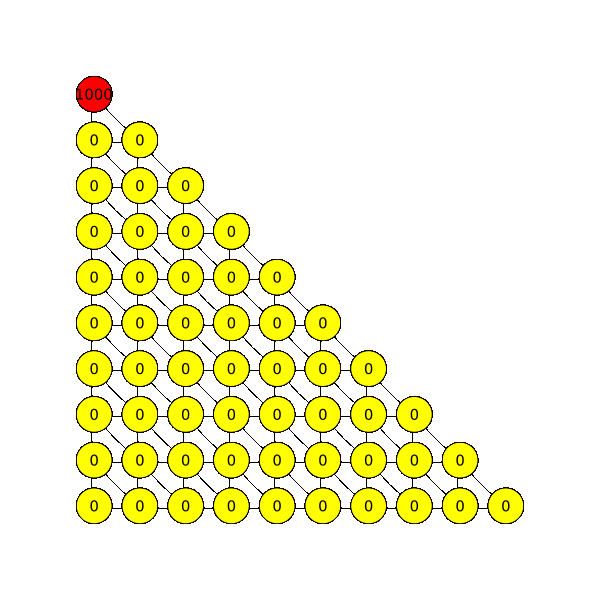

## Efficiency considerations

The power iteration in few lines of code:

```julia
function power_iteration(M, x, niter)
    for i in 1:niter
        x = M*x
        # Sometimes normalization is required
    end
    return x
end

# Dense transition matrix transposed
Pᵗ = transition(20) |> transpose |> Matrix;

# Initial iterate
nn = size(Pᵗ, 1) ; x = zeros(nn) ; x[1] = 1;
```

$~$

**Naive approach**: use dense data structure for $\mathsf P^T$

```julia
using GFlops
flops = @count_ops power_iteration(Pᵗ, x, 10)
memory = sizeof(Pᵗ)
println(flops, "\n", "Memory: $memory bytes")
```

```
Flop Counter: 882000 flop
┌─────┬─────────┐
│     │ Float64 │
├─────┼─────────┤
│ add │  441000 │
│ mul │  441000 │
└─────┴─────────┘
Memory: 352800 bytes
```

${\color{green} \rightarrow}$ time is wasted on 0s. Try `zeros(10_000, 10_000)^2`.

**Better solution**: use sparse data structure

```julia
import Base: *, transpose
struct coo_matrix
    rows::Array{Int}       # Row indices of ≠0
    cols::Array{Int}       # Column indices of ≠0
    vals::Array{Float64}   # Values of ≠0 entries
    m::Int                 # Number of rows
    n::Int                 # Number of columns
end

function transpose(A::coo_matrix)
    coo_matrix(A.cols, A.rows, A.vals, A.n, A.m)
end
```

${\color{green} \rightarrow}$ **Exercise**: define the `*` and `to_coo` functions

## Efficiency considerations

The power iteration in few lines of code:

```julia
function power_iteration(M, x, niter)
    for i in 1:niter
        x = M*x
        # Sometimes normalization is required
    end
    return x
end

# Dense transition matrix transposed
Pᵗ = transition(20) |> transpose |> Matrix;

# Initial iterate
nn = size(Pᵗ, 1) ; x = zeros(nn) ; x[1] = 1;
```

$~$

**Naive approach**: use dense data structure for $\mathsf P^T$

```julia
using GFlops
flops = @count_ops power_iteration(Pᵗ, x, 10)
memory = sizeof(Pᵗ)
println(flops, "\n", "Memory: $memory bytes")
```

```
Flop Counter: 882000 flop
┌─────┬─────────┐
│     │ Float64 │
├─────┼─────────┤
│ add │  441000 │
│ mul │  441000 │
└─────┴─────────┘
Memory: 352800 bytes
```

${\color{green} \rightarrow}$ time is wasted on 0s. Try `zeros(10_000, 10_000)^2`.

**Better solution**: use sparse data structure

```julia
using GFlops
sparse_Pᵗ = to_coo(Pᵗ)
flops = @count_ops power_iteration(sparse_Pᵗ, x, 10)
memory = sizeof(sparse_Pᵗ)
println(flops, "\n", "Memory: $memory bytes")
```

```
Flop Counter: 22800 flop
┌─────┬─────────┐
│     │ Float64 │
├─────┼─────────┤
│ add │   11400 │
│ mul │   11400 │
└─────┴─────────┘
Memory: 40 bytes
```

## Sparse matrix formats

We take the following matrix for illustration:
$$M = \begin{pmatrix} 5 & . & . \\ . & 6 & 7 \\ 8 & . & 9 \end{pmatrix}$$

- **Coordinate list** (COO), presented on the previous slide;
  - `rows` is `[1, 2, 2, 3, 3]`
  - `cols` is `[1, 2, 3, 1, 3]`
  - `vals` is `[5, 6, 7, 8, 9]`
- **Compressed sparse rows** (CSR):
  - Similar to COO, but often more memory-efficient: `rows` is compressed;
  - Vector `rows` contains the indices in `cols` and `vals` where rows start…
  - … except for `rows[m+1]`, which is 1 + the number of nonzeros;
  - `rows` is `[1, 2, 4, 6]`
  - `cols` is `[1, 2, 3, 1, 3]`
  - `vals` is `[5, 6, 7, 8, 9]`
- **Compressed sparse columns** (CSC):
  - Same as CSR with rows $\leftrightarrow$ columns;
  - Implemented in `julia` by `SparseArrays`.

```julia
using SparseArrays
Z = spzeros(3, 3)
```

```
3×3 SparseMatrixCSC{Float64, Int64} with 0 stored entries:
  ⋅    ⋅    ⋅
  ⋅    ⋅    ⋅
  ⋅    ⋅    ⋅
```

$~$

```julia
M = [5 0 0; 0 6 7; 8 0 9]
M = sparse(M)
```

```
3×3 SparseMatrixCSC{Int64, Int64} with 5 stored entries:
 5  ⋅  ⋅
 ⋅  6  7
 8  ⋅  9
```

$~$

```julia
# Constructor using COO format
M = sparse([1, 2, 2, 3, 3],
           [1, 2, 3, 1, 3],
           [5, 6, 7, 8, 9])
```

```
3×3 SparseMatrixCSC{Int64, Int64} with 5 stored entries:
 5  ⋅  ⋅
 ⋅  6  7
 8  ⋅  9
```

$~$

```julia
println(M.rowval)
println(M.colptr)
println(M.nzval)
```

```
[1, 3, 2, 2, 3]
[1, 3, 4, 6]
[5, 8, 6, 7, 9]
```

See also `sprand` and `spdiagm`.

# Simple vector iterations

## The power iteration

The **power iteration** is a method for finding $\color{blue}(\lambda_1, v_1)$:
$$\mathbf{\boldsymbol{x}}_{k+1} = \frac{\mathsf A \mathbf{\boldsymbol{x}}_{k}}{{\lVert {\mathsf A \mathbf{\boldsymbol{x}}_{k}} \rVert}},$$

- Normalization is necessary to avoid numerical `Inf`.
- Given $\mathbf{\boldsymbol{x}}_k \approx \mathbf{\boldsymbol{v}}_1$, the eigenvalue can be calculated from the Rayleigh quotient:
  $$\lambda_{1} \approx \frac{\mathbf{\boldsymbol{x}}_{k}^* \mathsf A \mathbf{\boldsymbol{x}}_k}{\mathbf{\boldsymbol{x}}_k^* \mathbf{\boldsymbol{x}}_k}$$

```julia
A = [2 1; 1 2]
x = rand(2)
for i in 1:20
    x = A*x
    x /= √(x'x)
end
println("Eigenvector: $x, eigenvalue: $(x'A*x)")
```

```
Eigenvector: [0.7071067812033929, 0.7071067811697023], eigenvalue: 3.0000000000000004
```

$~$

**Questions**:

- Does it converge and how quickly?
- What is a good stopping criterion?

## Convergence of the power iteration

**Notation**: let $\angle$ denote the acute angle between $\mathbf{\boldsymbol{x}}$ and $\mathbf{\boldsymbol{y}}$:
$$\angle(\mathbf{\boldsymbol{x}}, \mathbf{\boldsymbol{y}})
= \arccos\left( \frac{{\lvert {\mathbf{\boldsymbol{x}}^* \mathbf{\boldsymbol{y}}} \rvert}}{\sqrt{\mathbf{\boldsymbol{x}}^* \mathbf{\boldsymbol{x}}} \sqrt{\mathbf{\boldsymbol{y}}^* \mathbf{\boldsymbol{y}}}}\right).$$

Since the eigenvectors of $\mathsf A$ span $\mathbf C^n$, any vector $\mathbf{\boldsymbol{x}}_0$ may be decomposed uniquely as
$$\mathbf{\boldsymbol{x}}_0 = \alpha_1 \mathbf{\boldsymbol{v}}_1 + \dotsb + \alpha_n \mathbf{\boldsymbol{v}}_n.$$

**Proposition: convergence of the power iteration started from $\mathbf{\boldsymbol{x}}_0$**

Suppose that ${\lvert {\lambda_1} \rvert} > {\lvert {\lambda_2} \rvert}$ and $\alpha_1 \neq 0$. Then $(\mathbf{\boldsymbol{x}}_k)_{k \geqslant 0}$ satisfies
$$\lim_{k \to \infty} \angle(\mathbf{\boldsymbol{x}}_k, \mathbf{\boldsymbol{v}}_1) = 0.$$
The sequence $(\mathbf{\boldsymbol{x}}_k)$ is said to converge essentially to $\mathbf{\boldsymbol{v}}_1$. $~$

**Proof**

By construction
$$\mathbf{\boldsymbol{x}}_k
= \frac{\lambda_1^k \alpha_1 \mathbf{\boldsymbol{v}}_1 + \dotsb + \lambda_n^k \alpha_n \mathbf{\boldsymbol{v}}_n}{{\lVert {\lambda_1^k \alpha_1 \mathbf{\boldsymbol{v}}_1 + \dotsb + \lambda_n^k \alpha_n \mathbf{\boldsymbol{v}}_n} \rVert}}
= \frac{\lambda_1^k \alpha_1}{|\lambda_1^k \alpha_1|} \frac{\mathbf{\boldsymbol{v}}_1 + \frac{\lambda_2^k \alpha_2}{\lambda_1^k \alpha_1} \mathbf{\boldsymbol{v}}_2 + \dotsb + \frac{\lambda_n^k \alpha_2}{\lambda_1^k \alpha_1} \mathbf{\boldsymbol{v}}_n }{\left\lVert\mathbf{\boldsymbol{v}}_1 + \frac{\lambda_2^k \alpha_2}{\lambda_1^k \alpha_1} \mathbf{\boldsymbol{v}}_2 + \dotsb + \frac{\lambda_n^k \alpha_n}{\lambda_1^k \alpha_1} \mathbf{\boldsymbol{v}}_n\right\rVert}.$$
Therefore
$$\mathbf{\boldsymbol{x}}_k \left(\frac{|\lambda_1^k \alpha_1|}{\lambda_1^k \alpha_1}\right) \xrightarrow[k \to \infty]{} \mathbf{\boldsymbol{v}}_1.$$
(Notice that the bracketed factor on the left-hand side is a scalar of modulus 1.)

The dominant error term scales as $\color{red} |\lambda_2/\lambda_1|^k$.

## Inverse iteration

Suppose that $\mu \notin \sigma(\mathsf A)$ and $|\lambda_J - \mu| < |\lambda_K - \mu| \leqslant|\lambda_j - \mu|$ for all $j \neq J$.

**Question:** can we find $\lambda_J$, i.e. the eigenvalue that is nearest $\mu$?

**Idea**: apply the power iteration to $\mathsf B = (\mathsf A - \mu \mathsf I)^{-1}$:
$$\mathbf{\boldsymbol{x}}_{k+1} = \frac{\mathsf B \mathbf{\boldsymbol{x}}_{k}}{{\lVert {\mathsf B \mathbf{\boldsymbol{x}}_{k}} \rVert}}.$$

- The dominant eigenvalue of $\mathsf B$ is given by $(\lambda_J - \mu)^{-1}$.
- The associated eigenvector is $\mathbf{\boldsymbol{v}}_J$.
- Use `\` operator instead of calculating the inverse:

  ```julia
  A = [2 1; 1 2]
  x = rand(2)
  μ = 0
  B = A - μ*I
  for i in 1:10
      x = B\x
      x /= √(x'x)
      println("Eigenvector: $x, eigenvalue: $(x'A*x)")
  end
  ```

  ```
  Eigenvector: [-0.073395069620888, 0.9973029448243622], eigenvalue: 1.8536057618629984
  Eigenvector: [-0.4840913701752976, 0.8750174542955146], eigenvalue: 1.152823203245567
  Eigenvector: [-0.6363924079275455, 0.771365479608843], eigenvalue: 1.0182177300790847
  Eigenvector: [-0.6841587989671516, 0.7293330774041614], eigenvalue: 1.0020407154323043
  Eigenvector: [-0.6995341971283575, 0.7145991233187908], eigenvalue: 1.0002269520011233
  Eigenvector: [-0.7045913752929893, 0.7096132706360092], eigenvalue: 1.0000252194328363
  Eigenvector: [-0.7062692985764518, 0.7079432730723041], eigenvalue: 1.0000028021906129
  Eigenvector: [-0.706827730223213, 0.7073857220692972], eigenvalue: 1.0000003113549005
  Eigenvector: [-0.7070137764235103, 0.7071997737184075], eigenvalue: 1.0000000345949938
  Eigenvector: [-0.7070757809576499, 0.7071377800564256], eigenvalue: 1.0000000038438883
  ```

The dominant error term now scales as $\color{red} \left|\frac{\lambda_J - \mu} {\lambda_K - \mu}\right|^k$.

## Rayleigh quotient iteration

**Question**: can we adapt $\mu$ during the iteration in order to accelerate convergence?

- Error of the inverse iteration scales as $\color{red} \left|\frac{\lambda_J - \mu} {\lambda_K - \mu}\right|^k$.

  ${\color{green} \rightarrow}$ suggests letting

  $$\mu_k = \frac{\mathbf{\boldsymbol{x}}_k^* \mathsf A \mathbf{\boldsymbol{x}}_k}{\mathbf{\boldsymbol{x}}_k^* \mathbf{\boldsymbol{x}}_k}.$$

  This is the Rayleigh quotient iteration.
- If convergence to an eigenvector occurs, the associated eigenvalue converges cubically:

  $$|\lambda^{(k+1)} - \lambda_J| \leqslant C |\lambda^{(k)} - \lambda_J|^3.$$

  ${\color{green} \rightarrow}$ Number of significant digits is roughly tripled at each iteration.

```julia
A = [2 1; 1 2]
setprecision(500)
x = BigFloat.([1.2; 0.9])
μ = 0
for i in 1:6
    x = (A - μ*I)\x
    x /= √(x'x)
    μ = x'A*x
    println(μ)
end
```

```
2.689655172413793214338566074331922284628319727818488081860106227371262853189736760002654726539617400119969038165484095334893321873413803868251681795864
2.9876835222760986149331492272467355588185696109799282648595173771965397075426195063225678761434065353075142377089820027363840168362403721691362285304077
2.9999995241744513496497052218657690803207923292634754813048708145726507175594474194389978335452546331521437999768268695077710762632721314300139734193988
2.9999999999999999999730670707803381925912042248826047017208189162200256216460941091027939474791840614585910098581290345505474157692691833334644060848503
2.9999999999999999999999999999999999999999999999999999999999951158299301653110614230820165226784762374074665384291286744975203198864866424226623297764997
3.0000000000000000000000000000000000000000000000000000000000000000000000000000000000000000000000000000000000000000000000000000000000000000000000000000012
```

## Stopping criterion

A good stopping criterion is
$$\begin{equation}
\tag{stopping criterion}
{\lVert {\mathsf A \widehat {\mathbf{\boldsymbol{v}}} - \widehat \lambda \widehat {\mathbf{\boldsymbol{v}}}} \rVert} \leqslant\varepsilon {\lVert {\widehat {\mathbf{\boldsymbol{v}}}} \rVert}
\label{stopping}
\end{equation}$$

**Proposition: *forward* error estimate**

Suppose $\mathsf A$ is Hermitian and $\eqref{stopping}$ is satisfied. Then there exists $\lambda \in \sigma(\mathsf A)$ such that $|\lambda - \widehat \lambda| \leqslant\varepsilon$.

**Proof**

Let $\mathbf{\boldsymbol{r}} := \mathsf A \widehat {\mathbf{\boldsymbol{v}}} - \widehat \lambda \widehat {\mathbf{\boldsymbol{v}}}$. Then
$$\frac{1}{\min_{\lambda \in \sigma(\mathsf A)} |\lambda - \widehat \lambda|}
= {\lVert {(\mathsf A - \widehat \lambda \mathsf I)^{-1}} \rVert} \geqslant\frac{{\lVert {(\mathsf A - \widehat \lambda \mathsf I)^{-1}\mathbf{\boldsymbol{r}}} \rVert}}{{\lVert {\mathbf{\boldsymbol{r}}} \rVert}}
\geqslant\frac{1}{\varepsilon},$$
Taking the reciprocal, we deduce that
$$\min_{\lambda \in \sigma(\mathsf A)} |\lambda - \widehat \lambda| \leqslant\varepsilon,$$
which concludes the proof.

**Proposition: *backward* error estimate**

Suppose that $\eqref{stopping}$ is satisfied and let $\mathcal E = \Bigl\{\mathsf E \in \mathbf C^{n \times n}: (\mathsf A + \mathsf E) \widehat {\mathbf{\boldsymbol{v}}} = \widehat \lambda \widehat {\mathbf{\boldsymbol{v}}} \Bigr\}$. Then
$$\min_{\mathsf E \in \mathcal E} {\lVert {\mathsf E} \rVert} \leqslant\varepsilon.$$

Definition of the [backward error](https://nhigham.com/2020/03/25/what-is-backward-error/) by numerical analyst Nick Higham:

> Backward error is a measure of error associated with an approximate solution to a problem. Whereas the forward error is the distance between the approximate and true solutions, the backward error is how much the data must be perturbed to produce the approximate solution.

**Sketch of proof**

- Show first that any $\mathsf E \in \mathcal E$ satisfies $\mathsf E \widehat {\mathbf{\boldsymbol{v}}} = - \mathbf{\boldsymbol{r}}$, where $\mathbf{\boldsymbol{r}} := \mathsf A \widehat {\mathbf{\boldsymbol{v}}} - \widehat \lambda \widehat {\mathbf{\boldsymbol{v}}}$.
- Deduce from the first item that
  $$\inf_{\mathsf E \in \mathcal E} {\lVert {\mathsf E} \rVert} \geqslant\frac{{\lVert {\mathbf{\boldsymbol{r}}} \rVert}}{{\lVert {\widehat {\mathbf{\boldsymbol{v}}}} \rVert}}.$$
- Find a rank one matrix $\mathsf E_*$ such that ${\lVert {\mathsf E_*} \rVert} = \frac{{\lVert {\mathbf{\boldsymbol{r}}} \rVert}}{{\lVert {\widehat {\mathbf{\boldsymbol{v}}}} \rVert}}$, and then conclude.

  (Recall that any rank 1 matrix is of the form $\mathsf E_* = \mathbf{\boldsymbol{u}} \mathbf{\boldsymbol{w}}^*$, with norm ${\lVert {\mathbf{\boldsymbol{u}}} \rVert} {\lVert {\mathbf{\boldsymbol{w}}} \rVert}$.)

# Subspace iterations

## Simultaneous iteration

Suppose that $\mathsf X_0 \in \mathbf C^{n \times p}$ with $p < n$ and consider the iteration
$$\mathsf X_{k+1} = {\color{green}\text{normalization}} (\mathsf A \mathsf X_{k})$$

- For normalization, apply Gram–Schmidt to the columns;
- In practice, this can be achieved by QR decompostion:
  $$\mathsf X_{k+1} = \mathsf Q_{k+1},
  \qquad \mathsf Q_{k+1} \mathsf R_{k+1} = \mathsf A \mathsf X_k$$
  - $\mathsf Q_{k+1} \in \mathbf C^{n\times p}$ is a unitary matrix: $\mathsf Q_{k+1}^* \mathsf Q_{k+1} = \mathsf I_{p \times p}$;
  - $\mathsf R_{k+1} \in \mathbf C^{p\times p}$ is upper triangular.

**Some remarks:**

- The first column undergoes a simple power iteration;
- Mathematically, it is equivalent to apply the QR decomposition at the end. Indeed
  $$\mathsf X_{k} \underbrace{\mathsf R_{k} \mathsf R_{k-1} \dotsc \mathsf R_1}_{\text{upper tri.}}
  = \mathsf A \mathsf X_{k-1} \mathsf R_{k-1} \mathsf R_{k-2} \dotsc \mathsf R_{1}
  = \dots
  = \mathsf A^k \mathsf X_0.$$

  ${\color{green} \rightarrow}$ in particular, it holds that $\mathop{\mathrm{col}}(\mathsf X_k) = \mathop{\mathrm{col}}(\mathsf A^k \mathsf X_k)$.

## Convergence of the simultaneous iteration

**Theorem: Convergence of the simultaneous iteration**

Assume that

- $\mathsf A \in \mathbf C^{n \times n}$ is Hermitian
- $\mathsf X_0 \in \mathbf C^{n \times p}$ has linearly independent columns
- The subspace spanned by the columns of $\mathsf X_0$ satisfies
  $$\mathop{\mathrm{col}}(\mathsf X_0) \cap \mathop{\mathrm{Span}}\{ \mathbf{\boldsymbol{v}}_{p+1}, \dotsc, \mathbf{\boldsymbol{v}}_n \} = \varnothing.$$
- The first $p+1$ eigenvalues are distinct:
  $$|\lambda_1| > |\lambda_2| > \dotsb > |\lambda_p| > |\lambda_{p+1}| \geqslant|\lambda_{p+2}| \geqslant\dotsc \geqslant|\lambda_n|,$$
  Then the columns $\mathsf X_k$ converge essentially to $\mathbf{\boldsymbol{v}}_1, \dots, \mathbf{\boldsymbol{v}}_p$.

**Ideas of the proof**:

- Change coordinates so that $\mathsf A$ is diagonal;
- Show convergence of the orthogonal projector:
  $$\mathsf X_{k} \mathsf X_k^* \to \mathsf V_1 \mathsf V_1^*,
  \qquad \mathsf V_1 := \mathsf V\texttt{[:,1:p]}.$$
- Show by induction the essential convergence of each column.

## A particular case of the simultaneous iteration: $p = n$

Consider the following simultaneous iteration:
$${\color{magenta} \mathsf X_{k+1} \mathsf R_{k+1} = \mathsf A \mathsf X_{k}}~\text{(QR decomposition)}, \qquad \mathsf X_0 = \mathsf I_{\color{blue} n\times n}.$$
Let $\mathsf\Lambda_k := \mathsf X_k^* \mathsf A \mathsf X_k$.

- Under the conditions of the previous slide, it holds that $\mathsf\Lambda_k \to \mathsf D$.
- Now notice that
  - $\mathsf\Lambda_{k} = \mathsf X_{k}^* ({\color{magenta}\mathsf A \mathsf X_{k}}) = \mathsf X_{k}^* ({\color{magenta} \mathsf X_{k+1} \mathsf R_{k+1}}) = {\color{green}(\mathsf X_{k}^* \mathsf X_{k+1})} \color{blue} \mathsf R_{k+1}$
  - $\mathsf\Lambda_{k+1} = ({\color{magenta}\mathsf X_{k+1}^* \mathsf A}) \mathsf X_{k+1} = ({\color{magenta} \mathsf R_{k+1} \mathsf X_{k}^*}) \mathsf X_{k+1} = {\color{blue}\mathsf R_{k+1}} {\color{green}(\mathsf X_{k}^* \mathsf X_{k+1})}$

  Therefore, the eigenvalues may be obtained as follows

  ```julia
  A = [2 1; 1 2]
  Λ = A
  for i in 1:20
      Q, R = qr(Λ)
      Λ = R*Q
  end
  display(Λ)
  ```

  ```
  2×2 Matrix{Float64}:
   3.0          5.73594e-10
   5.73594e-10  1.0
  ```

  This is known as the *QR algorithm*.

**Historical remark**: the QR algorithm predates the simultaneous iteration:

- QR algorithm first proposed in 1959 here.
- First proof of convergence of simultatenous iteration in 1976 [here](https://link.springer.com/article/10.1007/BF01462265).

# Projection methods

## General projection method

**Idea**

Find approximate eigenvectors in a subspace $\mathcal U \subset \mathbf C^n$:
$$\tag{Galerkin condition}
\mathsf A \mathbf{\boldsymbol{v}} \approx \lambda \mathbf{\boldsymbol{v}}, \qquad \mathbf{\boldsymbol{v}} \in \mathcal U.$$

**Definition: Ritz vectors and Ritz values**

A vector $\widehat{\mathbf{\boldsymbol{v}}} \in \mathcal U$ is a Ritz vector of $\mathsf A$ relative to $\mathcal U$ associated with the Ritz value $\widehat \lambda$ if
$$\mathsf A \widehat{\mathbf{\boldsymbol{v}}} - \widehat \lambda \widehat{\mathbf{\boldsymbol{v}}} \perp \mathcal U.$$

**Remark**: If $\mathsf A \mathcal U \subset \mathcal U$, then every Ritz pair is an eigenpair.

**Finding Ritz vectors in practice**

Let $\mathsf U \in \mathbf C^{n \times p}$ be a matrix whose columns form an orthonormal basis of $\mathcal U$.

A pair $(\widehat {\mathbf{\boldsymbol{u}}}, \widehat \lambda) \in \mathbf C^p \times \mathbf C$ is solution of
$$\tag{Smaller eigenvalue problem}
\mathsf U^* \mathsf A \mathsf U \widehat{\mathbf{\boldsymbol{u}}} = \widehat \lambda \widehat{\mathbf{\boldsymbol{u}}},$$
if and only if $(\mathsf U \widehat{\mathbf{\boldsymbol{u}}}, \widehat \lambda)$ is a Ritz pair.

**General error estimate**

Let $\mathsf A$ be a full rank Hermitian matrix and $\mathcal U$ a $p$-dimensional subspace of $\mathbf C^n$. Then there are eigenvalues $\lambda_{i_1}, \dotsc, \lambda_{i_p}$ of $\mathsf A$ which satisfy
$$\forall j \in \{1, \dotsc, p\}, \qquad
{\lvert {\lambda_{i_j} - \widehat \lambda_j} \rvert} \leqslant{\lVert {(\mathsf I - \mathsf P_{\mathcal U}) \mathsf A \mathsf P_{\mathcal U}} \rVert},$$
where $\mathsf P_{\mathcal U} := \mathsf U \mathsf U^*$ is the orthogonal projector onto $\mathcal U$.

**Proposition: Property of Ritz values in Hermitian setting**

In the Hermitian setting, it holds that $\widehat \lambda_i \leqslant\lambda_i$.

**Proof**

Let $\mathsf H := \mathsf U^* \mathsf A \mathsf U$. By the Courant–Fisher theorem, it holds that
$$\widehat \lambda_i
= \max_{\mathcal S \subset \mathbf C^p, {\rm dim}(\mathcal S) = i} \left( \min_{\mathbf{\boldsymbol{x}} \in \mathcal S \backslash\{0\}} \frac{\mathbf{\boldsymbol{x}}^* \mathsf H \mathbf{\boldsymbol{x}}}{\mathbf{\boldsymbol{x}}^* \mathbf{\boldsymbol{x}}} \right)$$
Letting $\mathbf{\boldsymbol{y}} = \mathsf U \mathbf{\boldsymbol{x}}$ and then $\mathcal R = \mathsf U \mathcal S$, we deduce that
$$\begin{align*}
\widehat \lambda_i
&= \max_{\mathcal R \subset \mathcal U, {\rm dim}(\mathcal R) = i} \left( \min_{\mathbf{\boldsymbol{y}} \in \mathcal R \backslash\{0\}} \frac{\mathbf{\boldsymbol{y}}^* \mathsf A \mathbf{\boldsymbol{y}}}{\mathbf{\boldsymbol{y}}^* \mathbf{\boldsymbol{y}}} \right)
\leqslant\max_{\mathcal R \subset \mathbf C^n, {\rm dim}(\mathcal R) = i} \left( \min_{\mathbf{\boldsymbol{y}} \in \mathcal R \backslash\{0\}} \frac{\mathbf{\boldsymbol{y}}^* \mathsf A \mathbf{\boldsymbol{y}}}{\mathbf{\boldsymbol{y}}^* \mathbf{\boldsymbol{y}}} \right) = \lambda_i,
\end{align*}$$
where we used the Courant–Fisher for the matrix $\mathsf A$ in the last equality.

In particular
$$\widehat \lambda_1 = \max_{\mathbf{\boldsymbol{u}} \in \mathcal U \setminus \{0\}} \frac{\mathbf{\boldsymbol{u}}^* \mathsf A \mathbf{\boldsymbol{u}}}{\mathbf{\boldsymbol{u}}^* \mathbf{\boldsymbol{u}}}
\leqslant\max_{\mathbf{\boldsymbol{u}} \in \mathbf C^n \setminus \{0\}} \frac{\mathbf{\boldsymbol{u}}^* \mathsf A \mathbf{\boldsymbol{u}}}{\mathbf{\boldsymbol{u}}^* \mathbf{\boldsymbol{u}}}
= \lambda_1.$$

## Arnoldi iteration

The Arnoldi iteration is a projection method with $\mathcal U$ a Krylov subspace
$$\mathcal K_p(\mathsf A, \mathbf{\boldsymbol{u}}_0)
= \mathop{\mathrm{Span}}\Bigl\{ \mathbf{\boldsymbol{u}}_0, \mathsf A \mathbf{\boldsymbol{u}}_0, \mathsf A^2 \mathbf{\boldsymbol{u}}_0, \dotsc, \mathsf A^{p-1} \mathbf{\boldsymbol{u}}_0 \Bigr\}.$$
More precisely, it is a method for

- constructing the matrix $\mathsf U$ by Gram-Schmidt

  (i.e. constructing an orthonormal basis of $\mathcal K_k$)
- calculating the reduced matrix $\mathsf H := \mathsf U^* \mathsf A \mathsf U$.

```julia
function arnoldi(u₀, A, p)
    U = zeros(length(u₀), p)
    U[:, 1] = u₀ / √(u₀'u₀)
    H = zeros(p, p)
    for j in 1:p
        u = A*U[:, j]
        for i in 1:j
            H[i, j] = U[:, i]'u
            u -= H[i, j] * U[:, i]
        end
        if j < p
            H[j+1, j] = √(u'u)
            U[:, j+1] = u / H[j+1, j]
        end
    end
    return H, U
end ;
```

**Remarks**:

- The matrix $\mathsf H$ is of *Hessenberg form*.

```julia
n, p = 10, 5
A = rand(n, n)
u₀ = rand(n)
H, U = arnoldi(u₀, A, p)
display(H)
```

```
5×5 Matrix{Float64}:
 3.92498  0.770511   0.119577   0.948479   0.113864
 2.02973  0.81376    0.175274  -0.180263   0.49816
 0.0      0.550018  -0.346784  -0.156294   0.104327
 0.0      0.0        0.513835   0.488151  -0.00283717
 0.0      0.0        0.0        0.442819   0.128255
```

$~$

- Computational cost scales as $p^2$.

  ${\color{green} \rightarrow}$ Expensive for large $p$.

$~$

- Sometimes useful to restart iteration, e.g. when calculating dominant eigenpair:
  1. Perform $p$ iterations of Arnoldi;
  2. Calculate the associated Ritz vector $\widehat {\mathbf{\boldsymbol{v}}}_1$;
  3. Repeat with $\mathbf{\boldsymbol{u}}_0 = \widehat {\mathbf{\boldsymbol{v}}}_1$.

## Performance of Arnoldi iteration in practice

- Eigenvalues of large modulus tend to converge faster;
- But this observation still lacks a strong theoretical footing…

```julia
n, p = 40, 5
θ = LinRange(0, 6π, n)
A = (@. θ*cos(θ) + im*θ*sin(θ)) |> diagm
u₀ = rand(n)
true_λs = eigvals(A)
xlims = extrema(real.(true_λs)) .+ [-2; 2]
ylims = extrema(imag.(true_λs)) .+ [-2; 2]
anim = @animate for p ∈ 1:n
    H, U = arnoldi(u₀, A, p)
    λs = eigvals(H)
    heatmap(LinRange(xlims..., 100), LinRange(ylims..., 100), (x, y) -> √(x^2 + y^2), c=:viridis, alpha=.5, colorbar=:none)
    scatter!(real.(true_λs), imag.(true_λs), shape=:plus, color=:black, ms=6)
    scatter!(real.(λs), imag.(λs), label="Arnoldi")
    plot!(xlims=xlims, ylims=ylims, legend=:none, aspect_ratio=:equal, size=(900, 900))
    annotate!(-15, -17, "p = $p")
end
gif(anim, "arnoldi.gif", fps=2)
```

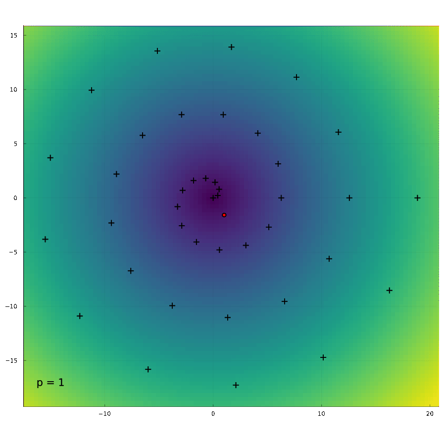

## Particular case of $\mathsf A$ Hermitian: Lanczos iteration

The Lanczos iteration is a particular case of Arnoldi’s method when $\mathsf A$ is Hermitian.
$$\mathcal K_p = \mathop{\mathrm{Span}}\Bigl\{ \mathbf{\boldsymbol{u}}_0, \mathsf A \mathbf{\boldsymbol{u}}_0, \mathsf A^2 \mathbf{\boldsymbol{u}}_0, \dotsc, \mathsf A^{p-1} \mathbf{\boldsymbol{u}}_0 \Bigr\}.$$

- Arnoldi’s iteration constructs orthonormal $\mathbf{\boldsymbol{u}}_0, \mathbf{\boldsymbol{u}}_1, \mathbf{\boldsymbol{u}}_2, \dotsc$ recursively as follows:
  $$\mathbf{\boldsymbol{u}}_{i+1} = \frac{\widehat {\mathbf{\boldsymbol{u}}}_{i+1}}{{\lVert {\widehat {\mathbf{\boldsymbol{u}}}_{i+1}} \rVert}},
  \qquad \widehat {\mathbf{\boldsymbol{u}}}_{i+1} = \mathsf A \mathbf{\boldsymbol{u}}_i - \sum_{j = 0}^i {\langle {\mathsf A \mathbf{\boldsymbol{u}}_i, \mathbf{\boldsymbol{u}}_j} \rangle} \mathbf{\boldsymbol{u}}_j.$$
- In the Hermitian setting,
  $${\langle {\mathsf A \mathbf{\boldsymbol{u}}_i, \mathbf{\boldsymbol{u}}_j} \rangle} = {\langle {\mathbf{\boldsymbol{u}}_i, \mathsf A \mathbf{\boldsymbol{u}}_j} \rangle}.$$
  Since $\mathsf A \mathbf{\boldsymbol{u}}_j \in \mathcal K_{j+1}(\mathsf A, \mathbf{\boldsymbol{u}}_0)$, this inner product is $0$ if $i \geqslant j+2$. Therefore
  $$\mathbf{\boldsymbol{u}}_{i+1} = \frac{\widehat {\mathbf{\boldsymbol{u}}}_{i+1}}{{\lVert {\widehat {\mathbf{\boldsymbol{u}}}_{i+1}} \rVert}},
  \qquad \widehat {\mathbf{\boldsymbol{u}}}_{i+1} = \mathsf A \mathbf{\boldsymbol{u}}_i - {\langle {\mathsf A \mathbf{\boldsymbol{u}}_i, \mathbf{\boldsymbol{u}}_{i-1}} \rangle} \mathbf{\boldsymbol{u}}_{i-1} - {\langle {\mathsf A \mathbf{\boldsymbol{u}}_i, \mathbf{\boldsymbol{u}}_i} \rangle} \mathbf{\boldsymbol{u}}_i.$$
  The matrix $\mathsf H := \mathsf U^* \mathsf A \mathsf U$ is tridiagonal in this case.

**Question**: which $\mathbf{\boldsymbol{v}}$ gives a better approximation $\frac{\mathbf{\boldsymbol{v}}^* \mathsf A \mathbf{\boldsymbol{v}}}{\mathbf{\boldsymbol{v}}^* \mathbf{\boldsymbol{v}}}$ of the dominant eigenvalue of $\mathsf A$?

- Power iteration: $\mathbf{\boldsymbol{v}} = \mathsf A^{p-1} \mathbf{\boldsymbol{x}}_0$.
- Lanczos iteration: $\mathbf{\boldsymbol{v}} = \widehat {\mathbf{\boldsymbol{v}}}_1$ the Ritz vector relative to $\mathcal K_{p}$ associated with the dominant Ritz value.